# Hello world - algorithmic trading with Python using quantopian platform

In this notebook I try to share basic introduction to algorithmic trading using quantopian platform specifically focusing the signle stock analysis

-`It is advised to use quantopian research environment to do all your analysis and coding strategies since it is quite time consuming to install all the libraries needed for quantopian enviornment`

-`Happy coding`

```python
import numpy as np
import pandas as pd
import matplotlib.pyplot as plt
```

```python
import seaborn as sns
sns.set_style('white', {"xtick.major.size": 2, "ytick.major.size": 2})
flatui = ["#9b59b6", "#3498db", "#95a5a6", "#e74c3c", "#34495e", "#2ecc71","#f4cae4"]
sns.set_palette(sns.color_palette(flatui,7))
```

# get_pricing

The `get_pricing` function provides access to 12 years of US Equity pricing data: the same data used by the Quantopian backtester.

`get_pricing` returns a **pandas object**. This could be a panel, dataframe or series depending on the input values.

```python
FB = get_pricing('FB',
                start_date='2017-07-04',
                end_date='2018-07-04',
                frequency='daily') #returns a pandas object dataframe when run for 1 security
```

```python
FB.head()
```

|  | open_price | high | low | close_price | volume | price |
| --- | --- | --- | --- | --- | --- | --- |
| 2017-07-05 00:00:00+00:00 | 149.00 | 150.850 | 148.13 | 150.340 | 11777310.0 | 150.340 |
| 2017-07-06 00:00:00+00:00 | 149.03 | 150.040 | 148.00 | 148.830 | 12330874.0 | 148.830 |
| 2017-07-07 00:00:00+00:00 | 149.25 | 151.990 | 149.19 | 151.440 | 11040933.0 | 151.440 |
| 2017-07-10 00:00:00+00:00 | 151.69 | 153.980 | 151.51 | 153.500 | 11068067.0 | 153.500 |
| 2017-07-11 00:00:00+00:00 | 153.37 | 155.423 | 152.91 | 155.279 | 11237695.0 | 155.279 |

```python
FB.tail()
```

|  | open_price | high | low | close_price | volume | price |
| --- | --- | --- | --- | --- | --- | --- |
| 2018-06-27 00:00:00+00:00 | 199.18 | 200.75 | 195.800 | 195.84 | 13842691.0 | 195.84 |
| 2018-06-28 00:00:00+00:00 | 195.18 | 197.34 | 193.260 | 196.23 | 14379789.0 | 196.23 |
| 2018-06-29 00:00:00+00:00 | 197.32 | 197.60 | 193.955 | 194.32 | 10759965.0 | 194.32 |
| 2018-07-02 00:00:00+00:00 | 193.37 | 197.45 | 192.220 | 197.40 | 10293968.0 | 197.40 |
| 2018-07-03 00:00:00+00:00 | 194.55 | 195.40 | 192.520 | 192.70 | 10566432.0 | 192.70 |

## Customize get_pricing

By default, `get_pricing` returns Open High Low Close Volume data at daily frequency for all of 2013 2014 . You can change the default behavior by passing the following parameters:

- Specify start and end dates by passing values to `start_date` and `end_date`. Dates can be passed as python `datetime` objects, pandas `Timestamp`s, or strings that can be parsed by pandas.
- Narrow the set of returned fields by passing strings or lists of strings as `fields`. Valid fields are:
  - `price`
  - `close_price` (an alias of price)
  - `open_price`
  - `high`
  - `low`
  - `volume`
- Access minutely or daily data by setting frequency to `frequency = daily` or `frequency='minute'`.

```
2019-01-02 00:00:00+00:00    156.643
2019-01-03 00:00:00+00:00    140.936
2019-01-04 00:00:00+00:00    147.061
2019-01-07 00:00:00+00:00    146.694
2019-01-08 00:00:00+00:00    149.550
Freq: C, Name: Equity(24 [AAPL]), dtype: float64
```

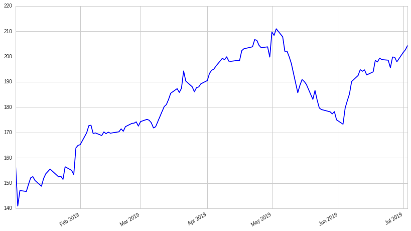

```python
aapl_daily_closes = get_pricing('AAPL',
                                fields='close_price', #modify to price, open_price, high, low or volume to change the field
                                start_date='2019-01-01', #customize your pricing date range
                                end_date = '2019-07-04',
                                frequency='daily') #change to hourly for hourly pricing

print(aapl_daily_closes.head())
# matplotlib is installed for easy plotting
aapl_daily_closes.plot(color='b');
```